# 102 - Quick-look Diagnostics

# Purpose

The main purpose of this template is to produce a **set of quick diagnostic plots** you can use during the early stages of model development to get a quick look at how your model fits the data.

This template will **create an HTML preview** of some typical diagnostic plots.

These plots are **not** intended to be report quality - please use the *pk-diagnostics-template.Rmd* template to create diagnostics suitable for your report.

# Model details - Run number: 102

── Status ─────────────────────────────────

• Finished Running

── Absolute Model Path ───────────────────────────

• /data/home/sethg/example-projects/page32-merge-workshop/model/pk/102

── YAML & Model Files ───────────────────────────

• /data/home/sethg/example-projects/page32-merge-workshop/model/pk/102.yaml

• /data/home/sethg/example-projects/page32-merge-workshop/model/pk/102.ctl

── Description ───────────────────────────────

• Two-compartment model with first-order absorption and linear elimination.

── Notes ──────────────────────────────────

• 1: Allometric scaling with weight reduces eta-V2 correlation with weight. Will consider additional RUV structures

• 2: Proportional RUV performed best over additive (103) and combined (104)

Dataset: ../../../data/derived/pk.csv

Records: 4292 Observations: 3142 Subjects: 160

Objective Function Value (final est. method): 30997.908

Estimation Method(s):

– First Order Conditional Estimation with Interaction

No Heuristic Problems Detected

| parameter_names | estimate | stderr | shrinkage |
| --- | --- | --- | --- |
| THETA1 | 0.434 | 0.0629 |  |
| THETA2 | 4.12 | 0.0276 |  |
| THETA3 | 1.12 | 0.0328 |  |
| THETA4 | 4.21 | 0.0192 |  |
| THETA5 | 1.29 | 0.0354 |  |
| OMEGA(1,1) | 0.221 | 0.0530 | 18.2 |
| OMEGA(2,2) | 0.0827 | 0.00983 | 6.32 |
| OMEGA(3,3) | 0.169 | 0.0197 | 0.898 |
| SIGMA(1,1) | 0.0399 | 0.00123 | 5.28 |

# Read in data

Use `bbr::nm_join()` to read in the input data set and join to any tables that were written out by the model. **This assumes that a row number column (called `NUM`) was included during data assembly.** The idea here is that in NONMEM, you table just `NUM` and none of the other input data items. They all will get joined back to the nonmem output … even character columns.

# General diagnostic plots

The following plots assume that the preferred x-axis labels are defined here.

## DV vs PRED and IPRED

Create plots of DV vs PRED and IPRED for the full dataset

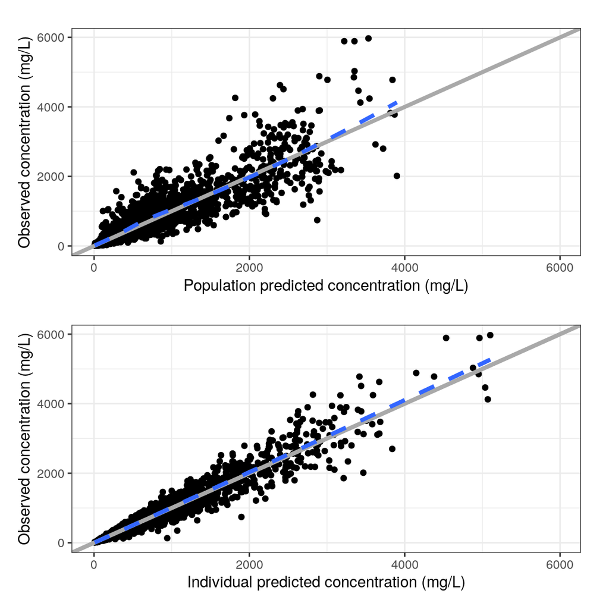

## NPDE plots

NPDE vs PRED, time and time after dose.

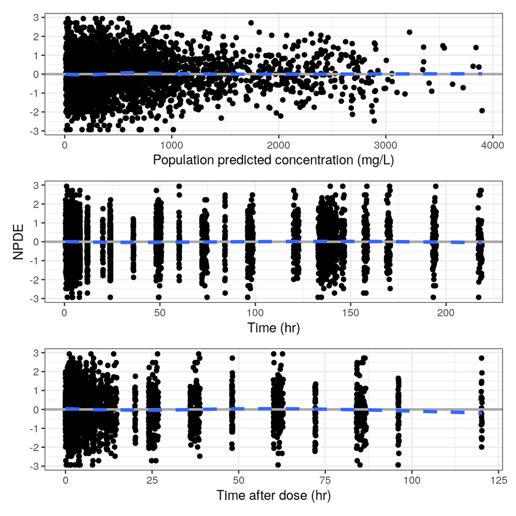

## NPDE density histogram

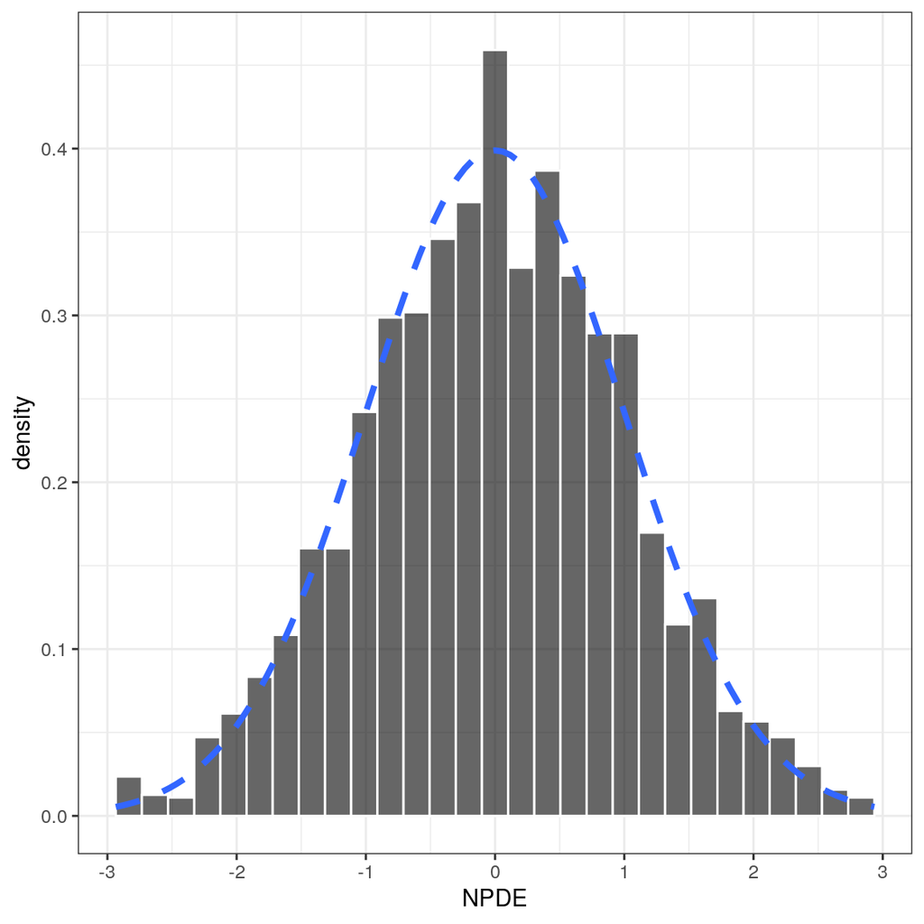

## CWRES vs PRED, time and time after dose

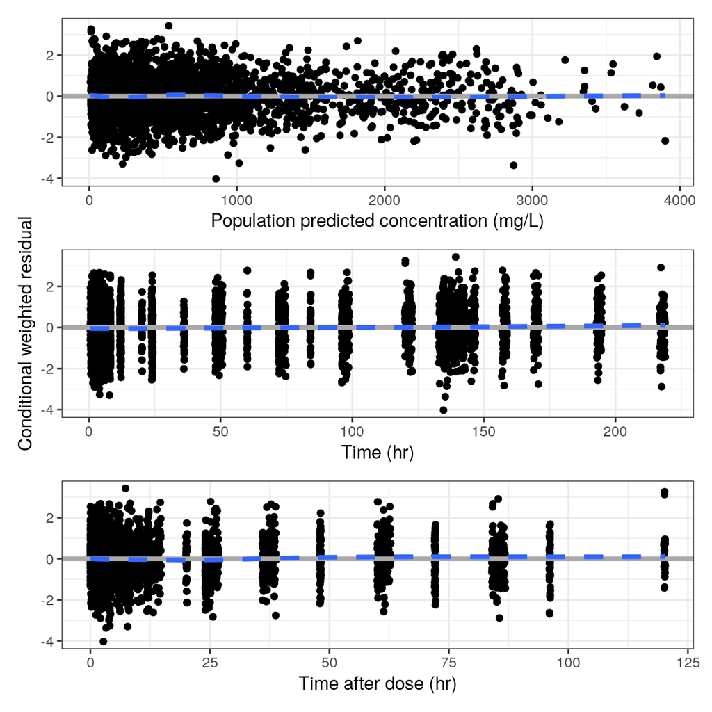

## CWRES qq and density plot

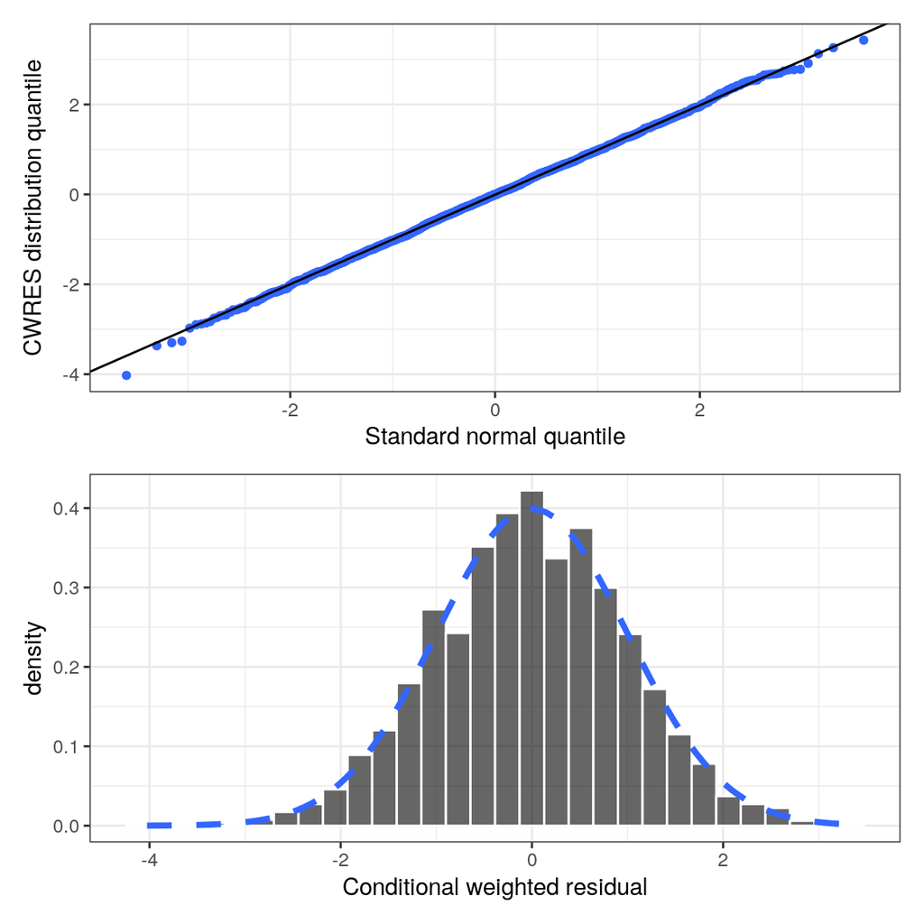

# EBEs-based diagnostics

## ETA pairs plot

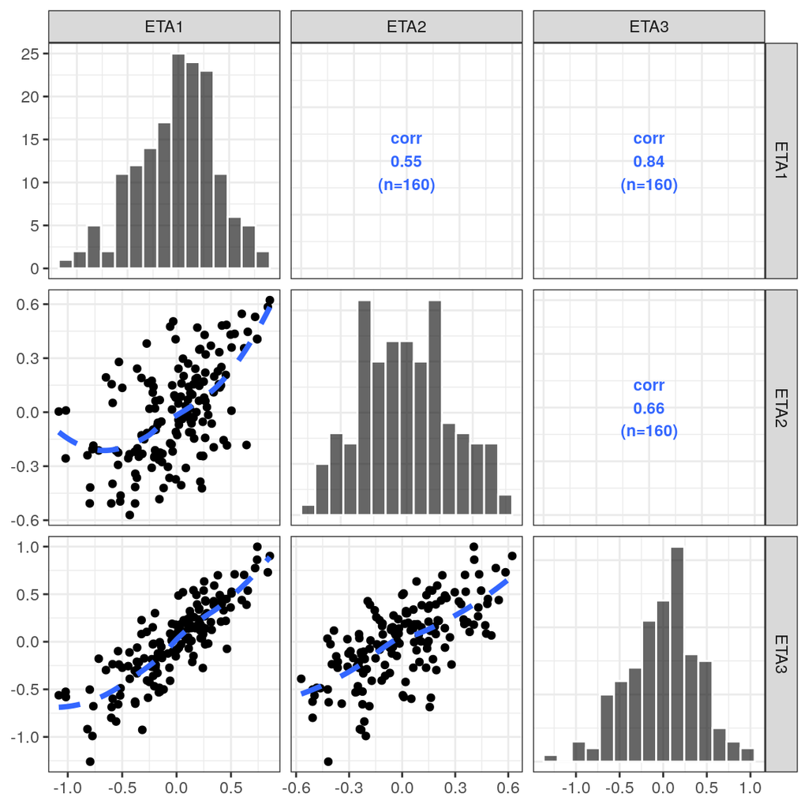